# ASVAB Performance Data Manager

Leandro Ledesma

2023-01-26

### Prepare the data for scoring

The ASVAB portion from Qualtrics was extract along with the ID variable. Some rows in the beginning of the dataset were removed since they were practice rounds from testers- not participants. The data set was converted to long format and each test type was identified and associated with an item.

```
   ID
1  47
2 100
3 140
4 149
```

```
[1] "The following IDs were removed from further analysis for having duplicates 47"
[2] "The following IDs were removed from further analysis for having duplicates 100"
[3] "The following IDs were removed from further analysis for having duplicates 140"
[4] "The following IDs were removed from further analysis for having duplicates 149"
```

```
[1] "GS"  "AR"  "WK"  "PC"  "MK"  "EI"  "ASI" "MC"  "AO"
```

### Scoring the data

```r
# Add the correct responses as a variable
ASVAB.long2 %>%
  group_by(ID, Subject) %>%
  summarize(length = length(Subject))
```

```
# A tibble: 2,124 × 3
# Groups:   ID [236]
      ID Subject length
   <dbl> <chr>    <int>
 1     1 AO          25
 2     1 AR          30
 3     1 ASI         25
 4     1 EI          20
 5     1 GS          25
 6     1 MC          25
 7     1 MK          25
 8     1 PC          15
 9     1 WK          35
10     2 AO          25
# … with 2,114 more rows
```

```r
# join the ASVAB responses and the correct responses together
ASVAB.joined <- ASVAB.long2 %>%
  full_join(Answer_Key, by = c("Subject", "Question #"))

# Create a received variable, as in was the question asked
ASVAB.joined <- ASVAB.joined %>%
  mutate(Received = ifelse(Response == "", 0, 1))

# Rearrange the order of the variables
ASVAB.joined <- ASVAB.joined %>%
  select(ID, Type, Subject, `Question #`, Received, Response, Answer)


# Extra cleaning before scoring the data [IMPORTANT]
ASVAB.joined <- ASVAB.joined %>%
  mutate(Response = ifelse(Response == "Both perform similar functions in different food chains ",
                                       "Both perform similar functions in different food chains",
                                        Response))

# Create a scoring variable
ASVAB.scored <- ASVAB.joined %>%
  mutate(Score = ifelse(Response == Answer, 1, 0))

# Obtain a proportion score for correct responses by Subject
ASVAB.final <- ASVAB.scored %>%
  group_by(ID, Subject) %>%
  summarize(num.correct = sum(Score),
            total.Q = sum(Received),
            mean.percent = round(num.correct/total.Q,3)*100)
```

### Quality Check

There may be cases where subjects get a correct answer incorrectly because the string saved from qualtrics has an additional space in the text. This mismatch will make the item scored as a 0 instead of a 1. We can identify which responses have this extra space and then correct for it in the previous code chunck.

The following has been inspected manually and deemed to be correct. Fuzzy matching is comparing all answers in one vector vs another, however, there are cases where (A) 20 will be the wrong answer in one question but the right answer in another, thus that’s why it looks like there are errors- but there are none.

Additionally, below is a table showing the number of items from each subtest presented to participants. It seems not everyone got the same number of items, but most did.

```r
# Checking how many items there are per question
Subject.item.count <- ASVAB.final %>%
  mutate(total.Q = as.character(total.Q)) %>%
  count(Subject, total.Q)

table(Subject.item.count$Subject, Subject.item.count$total.Q)
```

```
        0  10  11  12  13  14  15   3   5   7   8   9
  AO    2   0   5 227   0   0   0   1   1   0   0   0
  AR    1   1   5   4   4 218   0   0   2   0   0   1
  ASI   2   0   1 231   0   0   0   0   1   1   0   0
  EI    2 229   0   0   0   0   0   0   1   1   2   1
  GS    1   0   0 235   0   0   0   0   0   0   0   0
  MC    2   0   1 232   0   0   0   0   1   0   0   0
  MK    2   4   4 224   0   0   0   0   1   0   1   0
  PC    2   8  10  13   5   7 189   0   0   1   0   1
  WK    2   0   0   0   0   0 233   0   1   0   0   0
```

```r
# Manually inspect some
Subject.item.count %>%
  filter(Subject == "AR" & total.Q == "26")
```

```
# A tibble: 0 × 4
# Groups:   ID [0]
# … with 4 variables: ID <dbl>, Subject <chr>, total.Q <chr>, n <int>
```

```r
# View all questions that were received that were marked as incorrect
should.be.incorrect_df <- ASVAB.scored %>%
  filter(Received == 1 & Score == 0)


response_df <- should.be.incorrect_df %>%
  select(ID, Subject, Answer = Response)

answer_df <- should.be.incorrect_df %>%
  select(ID, Subject, Answer)


library(fuzzyjoin)
# Fuzzy matching between incorrect answers and correct responses
stringdist_join(response_df, answer_df,
                by='Answer', #match based on team
                mode='left', #use left join
                method = "jw", #use jw distance metric
                max_dist=99,
                distance_col='dist') %>%
  group_by(Subject.x) %>%
  slice_min(order_by=dist, n=1) %>%
  select(-ID.y) %>%
  unique() %>%
  arrange(dist)
```

```
# A tibble: 376 × 6
# Groups:   Subject.x [9]
    ID.x Subject.x Answer.x Subject.y Answer.y  dist
   <dbl> <chr>     <chr>    <chr>     <chr>    <dbl>
 1     5 AR        (B) 10   MK        (B) 10       0
 2    11 AR        (A) 20   AR        (A) 20       0
 3    12 AR        (C) 87   AR        (C) 87       0
 4    14 AR        (C) 12   MK        (C) 12       0
 5    15 AR        (C) 12   MK        (C) 12       0
 6    15 AR        (D) 8    AR        (D) 8        0
 7    18 AR        (C) 12   MK        (C) 12       0
 8    18 AR        (B) 10   MK        (B) 10       0
 9    20 AR        (B) 10   MK        (B) 10       0
10    21 AR        (C) 12   MK        (C) 12       0
# … with 366 more rows
```

### Check overall performance

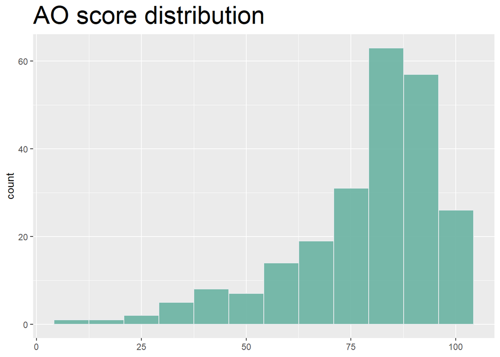

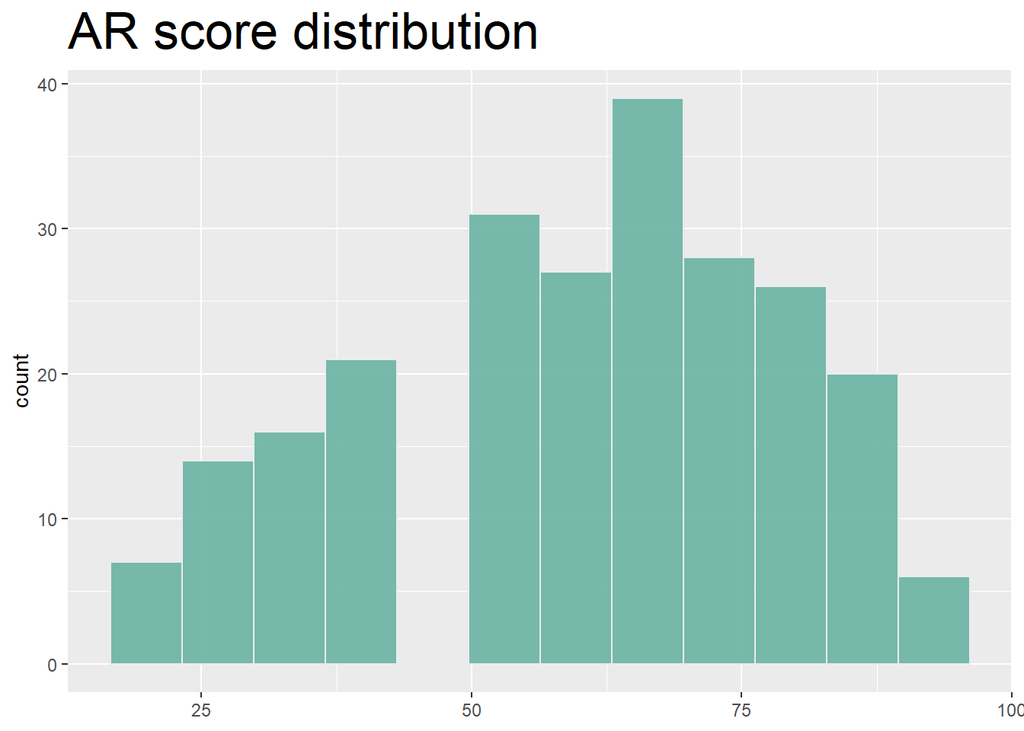

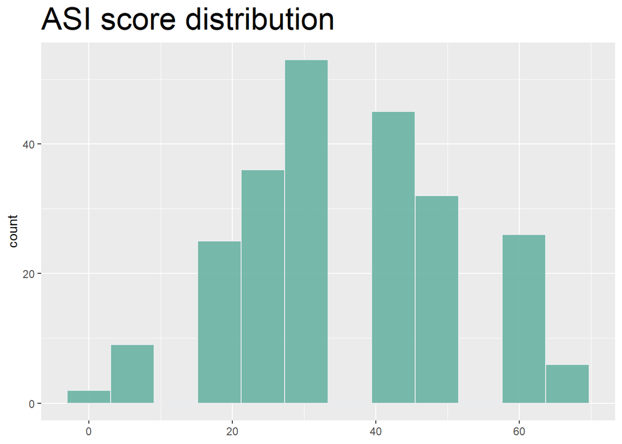

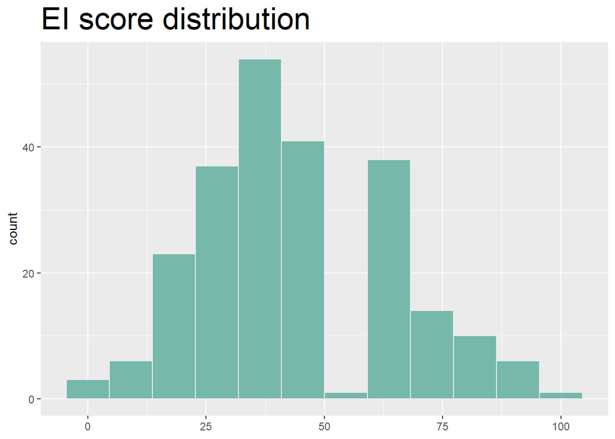

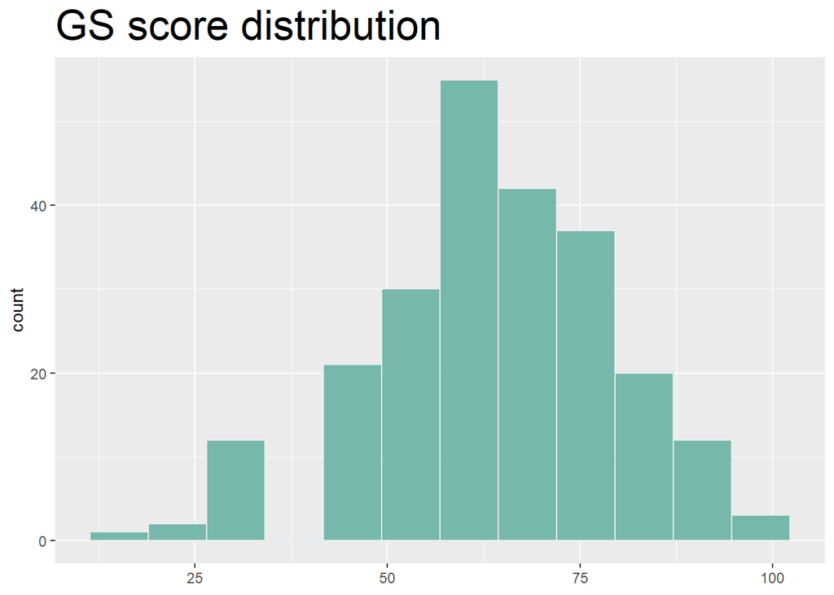

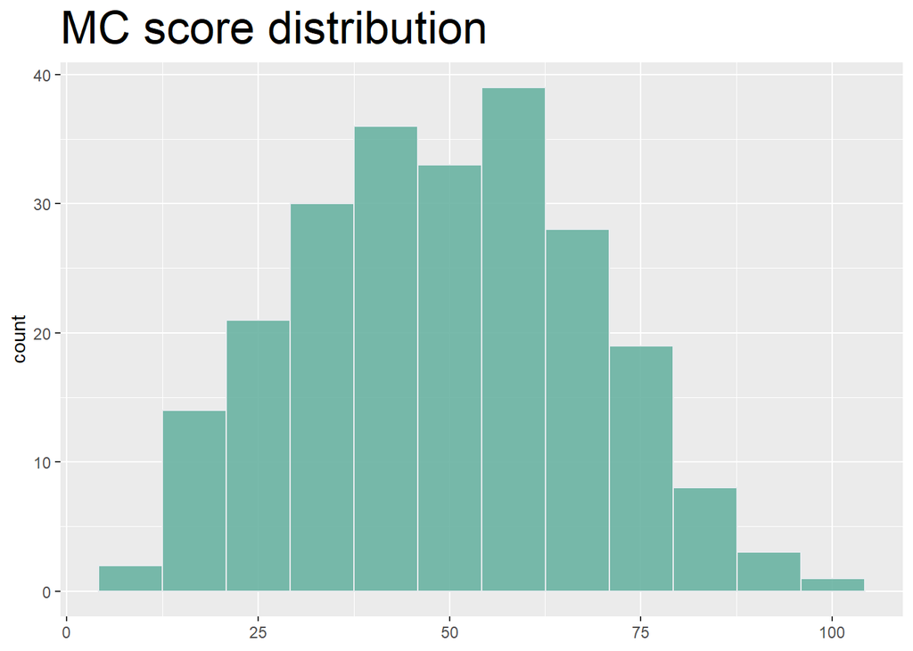

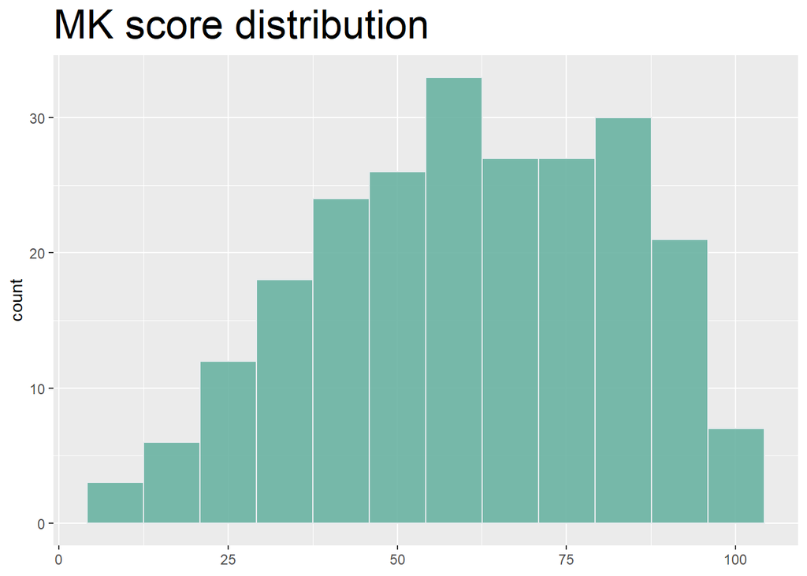

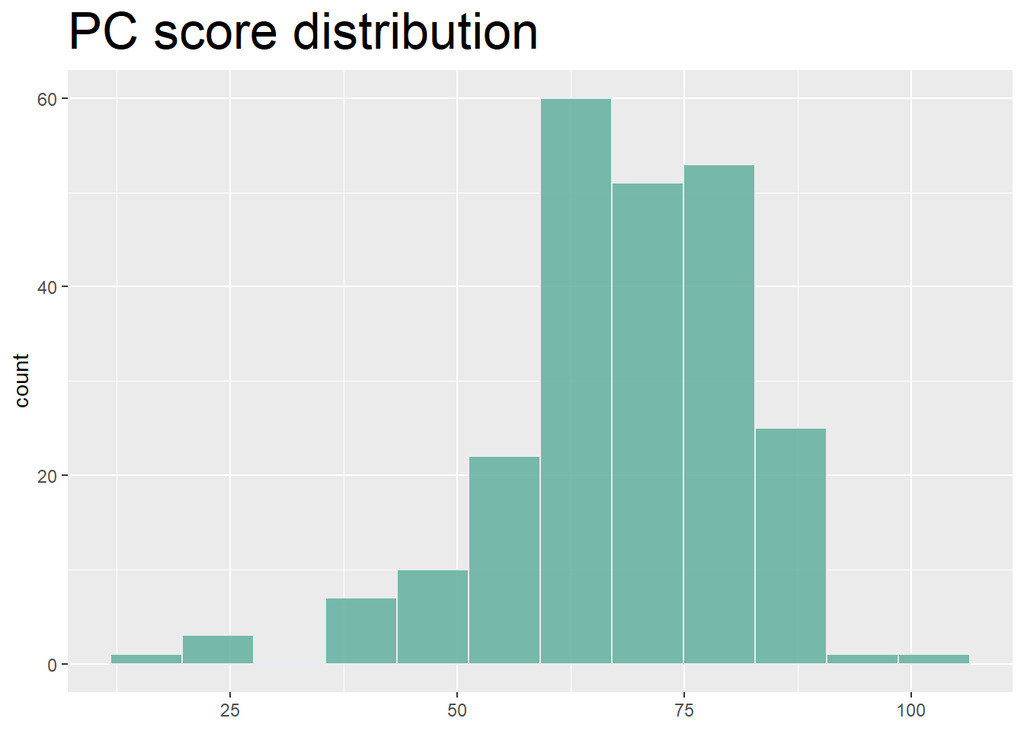

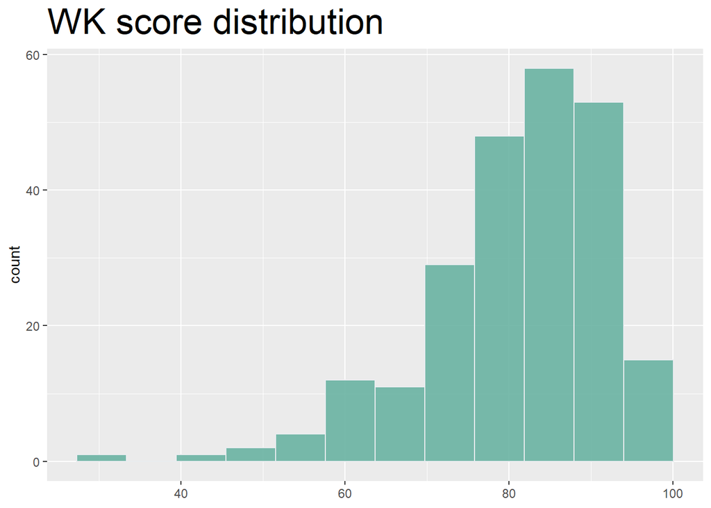

```r
all.subjects <- unique(ASVAB.final$Subject)


all.plots <- list()

for(ii in 1:length(all.subjects)) {

all.plots[[ii]] <- ASVAB.final %>%
  filter(Subject == all.subjects[ii]) %>%
  ggplot(aes(x = mean.percent)) +
  geom_histogram(bins = 12, fill="#69b3a2", color="#e9ecef", alpha=0.9) +
  ggtitle(paste(all.subjects[ii],"score distribution")) +
  theme(axis.title.x = element_blank()) +
  theme(plot.title = element_text(size=25))

}


all.plots
```

### Save the data

```r
# Save the data
setwd("~/ONR/ASVAB/Processed Data")

write_csv(ASVAB.final, file = "ASVAB.scored.csv")
```